# Exploratory Data Analysis (EDA) on US Accidents Dataset

## Step 1: Importing the required libraries

```python
# Essential libraries for EDA
import pandas as pd
import numpy as np
import matplotlib.pyplot as plt
import seaborn as sns
import plotly.express as px
import scipy
```

## Step 2: Loading the Data

```python
#Load dataset
df = pd.read_csv('us-accidents-sample-1M.csv')
print(df)
```

```
               ID   Source  Severity           Start_Time  \
0             A-3  Source2         2  2016-02-08 06:49:27
1             A-6  Source2         3  2016-02-08 07:44:26
2             A-7  Source2         2  2016-02-08 07:59:35
3            A-15  Source2         2  2016-02-08 08:39:43
4            A-39  Source2         2  2016-02-09 05:17:08
...           ...      ...       ...                  ...
999995  A-7777735  Source1         4  2019-08-23 13:39:48
999996  A-7777747  Source1         2  2019-08-23 16:26:06
999997  A-7777748  Source1         4  2019-08-23 16:51:29
999998  A-7777750  Source1         2  2019-08-23 17:10:58
999999  A-7777758  Source1         2  2019-08-23 19:11:30

                   End_Time  Start_Lat   Start_Lng   End_Lat    End_Lng  \
0       2016-02-08 07:19:27  39.063148  -84.032608       NaN        NaN
```

[output cut: 51 more lines]

```python
#Initial inspection
print("Dataset shape: ", df.shape)
print("\nFirst 5 rows: ")
df.head()
```

```
Dataset shape:  (1000000, 46)

First 5 rows:
```

|  | ID | Source | Severity | Start_Time | End_Time | Start_Lat | Start_Lng | End_Lat | End_Lng | Distance(mi) | ... | Roundabout | Station | Stop | Traffic_Calming | Traffic_Signal | Turning_Loop | Sunrise_Sunset | Civil_Twilight | Nautical_Twilight | Astronomical_Twilight |
| --- | --- | --- | --- | --- | --- | --- | --- | --- | --- | --- | --- | --- | --- | --- | --- | --- | --- | --- | --- | --- | --- |
| 0 | A-3 | Source2 | 2 | 2016-02-08 06:49:27 | 2016-02-08 07:19:27 | 39.063148 | -84.032608 | NaN | NaN | 0.01 | ... | False | False | False | False | True | False | Night | Night | Day | Day |
| 1 | A-6 | Source2 | 3 | 2016-02-08 07:44:26 | 2016-02-08 08:14:26 | 40.100590 | -82.925194 | NaN | NaN | 0.01 | ... | False | False | False | False | False | False | Day | Day | Day | Day |
| 2 | A-7 | Source2 | 2 | 2016-02-08 07:59:35 | 2016-02-08 08:29:35 | 39.758274 | -84.230507 | NaN | NaN | 0.00 | ... | False | False | False | False | False | False | Day | Day | Day | Day |
| 3 | A-15 | Source2 | 2 | 2016-02-08 08:39:43 | 2016-02-08 09:09:43 | 39.972038 | -82.913521 | NaN | NaN | 0.01 | ... | False | False | False | False | True | False | Day | Day | Day | Day |
| 4 | A-39 | Source2 | 2 | 2016-02-09 05:17:08 | 2016-02-09 05:47:08 | 39.782578 | -84.178688 | NaN | NaN | 0.01 | ... | False | False | False | False | False | False | Night | Night | Night | Night |

5 rows × 46 columns

## Step 3: Initial Data Exploration

```python
# 1. Get the information about dataset
print("Data types and non-null counts: ")
print(df.info())
```

```
Data types and non-null counts:
<class 'pandas.core.frame.DataFrame'>
RangeIndex: 1000000 entries, 0 to 999999
Data columns (total 46 columns):
 #   Column                 Non-Null Count    Dtype
---  ------                 --------------    -----
 0   ID                     1000000 non-null  object
 1   Source                 1000000 non-null  object
 2   Severity               1000000 non-null  int64
 3   Start_Time             1000000 non-null  object
 4   End_Time               1000000 non-null  object
 5   Start_Lat              1000000 non-null  float64
 6   Start_Lng              1000000 non-null  float64
 7   End_Lat                560122 non-null   float64
 8   End_Lng                560122 non-null   float64
```

[output cut: 40 more lines]

```python
# 2. Get the statistical information
print("Statistical summary: ")
display(df.describe())  # display function for better readability
```

```
Statistical summary:
```

|  | Severity | Start_Lat | Start_Lng | End_Lat | End_Lng | Distance(mi) | Temperature(F) | Wind_Chill(F) | Humidity(%) | Pressure(in) | Visibility(mi) | Wind_Speed(mph) | Precipitation(in) |
| --- | --- | --- | --- | --- | --- | --- | --- | --- | --- | --- | --- | --- | --- |
| count | 1000000.000000 | 1000000.000000 | 1000000.000000 | 560122.000000 | 560122.000000 | 1000000.000000 | 978905.000000 | 741428.000000 | 977637.000000 | 981869.000000 | 977124.000000 | 926201.000000 | 715363.000000 |
| mean | 2.212728 | 36.210188 | -94.697790 | 36.268519 | -95.708158 | 0.562804 | 61.657002 | 58.224790 | 64.846766 | 29.537666 | 9.087955 | 7.690723 | 0.008318 |
| std | 0.488370 | 5.078645 | 17.388088 | 5.275009 | 18.095025 | 1.786890 | 19.016397 | 22.385673 | 22.813335 | 1.005614 | 2.702145 | 5.451975 | 0.103407 |
| min | 1.000000 | 24.555269 | -124.497567 | 24.569978 | -124.497478 | 0.000000 | -89.000000 | -89.000000 | 1.000000 | 0.290000 | 0.000000 | 0.000000 | 0.000000 |
| 25% | 2.000000 | 33.406755 | -117.213699 | 33.462100 | -117.740369 | 0.000000 | 49.000000 | 42.600000 | 48.000000 | 29.370000 | 10.000000 | 4.600000 | 0.000000 |
| 50% | 2.000000 | 35.831512 | -87.778374 | 36.187096 | -88.022659 | 0.030000 | 64.000000 | 62.000000 | 67.000000 | 29.860000 | 10.000000 | 7.000000 | 0.000000 |
| 75% | 2.000000 | 40.096065 | -80.351738 | 40.191142 | -80.249905 | 0.465000 | 76.000000 | 75.000000 | 84.000000 | 30.030000 | 10.000000 | 10.400000 | 0.000000 |
| max | 4.000000 | 49.000759 | -67.403551 | 49.000760 | -67.403550 | 176.279999 | 207.000000 | 207.000000 | 100.000000 | 58.390000 | 120.000000 | 822.800000 | 25.000000 |

```python
#for both numerical and catagorical columns
display(df.describe(include='all').transpose())
```

|  | count | unique | top | freq | mean | std | min | 25% | 50% | 75% | max |
| --- | --- | --- | --- | --- | --- | --- | --- | --- | --- | --- | --- |
| ID | 1000000 | 1000000 | A-3 | 1 | NaN | NaN | NaN | NaN | NaN | NaN | NaN |
| Source | 1000000 | 3 | Source1 | 560122 | NaN | NaN | NaN | NaN | NaN | NaN | NaN |
| Severity | 1000000.0 | NaN | NaN | NaN | 2.212728 | 0.48837 | 1.0 | 2.0 | 2.0 | 2.0 | 4.0 |
| Start_Time | 1000000 | 952419 | 2021-01-26 16:16:13 | 27 | NaN | NaN | NaN | NaN | NaN | NaN | NaN |
| End_Time | 1000000 | 976257 | 2017-05-15 15:22:55 | 12 | NaN | NaN | NaN | NaN | NaN | NaN | NaN |
| Start_Lat | 1000000.0 | NaN | NaN | NaN | 36.210188 | 5.078645 | 24.555269 | 33.406755 | 35.831512 | 40.096065 | 49.000759 |
| Start_Lng | 1000000.0 | NaN | NaN | NaN | -94.69779 | 17.388088 | -124.497567 | -117.213699 | -87.778374 | -80.351738 | -67.403551 |
| End_Lat | 560122.0 | NaN | NaN | NaN | 36.268519 | 5.275009 | 24.569978 | 33.4621 | 36.187096 | 40.191142 | 49.00076 |
| End_Lng | 560122.0 | NaN | NaN | NaN | -95.708158 | 18.095025 | -124.497478 | -117.740369 | -88.022659 | -80.249905 | -67.40355 |
| Distance(mi) | 1000000.0 | NaN | NaN | NaN | 0.562804 | 1.78689 | 0.0 | 0.0 | 0.03 | 0.465 | 176.279999 |
| Description | 999999 | 747382 | A crash has occurred causing no to minimum del... | 1271 | NaN | NaN | NaN | NaN | NaN | NaN | NaN |
| Street | 998532 | 130147 | I-95 N | 10226 | NaN | NaN | NaN | NaN | NaN | NaN | NaN |
| City | 999970 | 10808 | Miami | 24353 | NaN | NaN | NaN | NaN | NaN | NaN | NaN |
| County | 1000000 | 1705 | Los Angeles | 68263 | NaN | NaN | NaN | NaN | NaN | NaN | NaN |
| State | 1000000 | 49 | CA | 225116 | NaN | NaN | NaN | NaN | NaN | NaN | NaN |
| Zipcode | 999745 | 217017 | 91761 | 1480 | NaN | NaN | NaN | NaN | NaN | NaN | NaN |
| Country | 1000000 | 1 | US | 1000000 | NaN | NaN | NaN | NaN | NaN | NaN | NaN |
| Timezone | 998983 | 4 | US/Eastern | 463163 | NaN | NaN | NaN | NaN | NaN | NaN | NaN |
| Airport_Code | 997089 | 1964 | KCQT | 15205 | NaN | NaN | NaN | NaN | NaN | NaN | NaN |
| Weather_Timestamp | 984486 | 387171 | 2022-03-13 01:53:00 | 159 | NaN | NaN | NaN | NaN | NaN | NaN | NaN |
| Temperature(F) | 978905.0 | NaN | NaN | NaN | 61.657002 | 19.016397 | -89.0 | 49.0 | 64.0 | 76.0 | 207.0 |
| Wind_Chill(F) | 741428.0 | NaN | NaN | NaN | 58.22479 | 22.385673 | -89.0 | 42.6 | 62.0 | 75.0 | 207.0 |
| Humidity(%) | 977637.0 | NaN | NaN | NaN | 64.846766 | 22.813335 | 1.0 | 48.0 | 67.0 | 84.0 | 100.0 |
| Pressure(in) | 981869.0 | NaN | NaN | NaN | 29.537666 | 1.005614 | 0.29 | 29.37 | 29.86 | 30.03 | 58.39 |
| Visibility(mi) | 977124.0 | NaN | NaN | NaN | 9.087955 | 2.702145 | 0.0 | 10.0 | 10.0 | 10.0 | 120.0 |
| Wind_Direction | 977275 | 24 | CALM | 124367 | NaN | NaN | NaN | NaN | NaN | NaN | NaN |
| Wind_Speed(mph) | 926201.0 | NaN | NaN | NaN | 7.690723 | 5.451975 | 0.0 | 4.6 | 7.0 | 10.4 | 822.8 |
| Precipitation(in) | 715363.0 | NaN | NaN | NaN | 0.008318 | 0.103407 | 0.0 | 0.0 | 0.0 | 0.0 | 25.0 |
| Weather_Condition | 977581 | 115 | Fair | 330917 | NaN | NaN | NaN | NaN | NaN | NaN | NaN |
| Amenity | 1000000 | 2 | False | 987520 | NaN | NaN | NaN | NaN | NaN | NaN | NaN |
| Bump | 1000000 | 2 | False | 999567 | NaN | NaN | NaN | NaN | NaN | NaN | NaN |
| Crossing | 1000000 | 2 | False | 886756 | NaN | NaN | NaN | NaN | NaN | NaN | NaN |
| Give_Way | 1000000 | 2 | False | 995343 | NaN | NaN | NaN | NaN | NaN | NaN | NaN |
| Junction | 1000000 | 2 | False | 926173 | NaN | NaN | NaN | NaN | NaN | NaN | NaN |
| No_Exit | 1000000 | 2 | False | 997461 | NaN | NaN | NaN | NaN | NaN | NaN | NaN |
| Railway | 1000000 | 2 | False | 991231 | NaN | NaN | NaN | NaN | NaN | NaN | NaN |
| Roundabout | 1000000 | 2 | False | 999976 | NaN | NaN | NaN | NaN | NaN | NaN | NaN |
| Station | 1000000 | 2 | False | 973764 | NaN | NaN | NaN | NaN | NaN | NaN | NaN |
| Stop | 1000000 | 2 | False | 972094 | NaN | NaN | NaN | NaN | NaN | NaN | NaN |
| Traffic_Calming | 1000000 | 2 | False | 999040 | NaN | NaN | NaN | NaN | NaN | NaN | NaN |
| Traffic_Signal | 1000000 | 2 | False | 852050 | NaN | NaN | NaN | NaN | NaN | NaN | NaN |
| Turning_Loop | 1000000 | 1 | False | 1000000 | NaN | NaN | NaN | NaN | NaN | NaN | NaN |
| Sunrise_Sunset | 996947 | 2 | Day | 690447 | NaN | NaN | NaN | NaN | NaN | NaN | NaN |
| Civil_Twilight | 996947 | 2 | Day | 737088 | NaN | NaN | NaN | NaN | NaN | NaN | NaN |
| Nautical_Twilight | 996947 | 2 | Day | 786350 | NaN | NaN | NaN | NaN | NaN | NaN | NaN |
| Astronomical_Twilight | 996947 | 2 | Day | 825558 | NaN | NaN | NaN | NaN | NaN | NaN | NaN |

```python
# 3. Checking missing values
missing = df.isnull().sum().sort_values(ascending = False)
missing_percentage = (missing / len(df)) * 100
```

```python
missing_df = pd.concat([missing, missing_percentage], keys=['No of missing values', 'Missing values %'], axis=1)
display(missing_df[missing_df['Missing values %']>0])
```

|  | No of missing values | Missing values % |
| --- | --- | --- |
| End_Lat | 439878 | 43.9878 |
| End_Lng | 439878 | 43.9878 |
| Precipitation(in) | 284637 | 28.4637 |
| Wind_Chill(F) | 258572 | 25.8572 |
| Wind_Speed(mph) | 73799 | 7.3799 |
| Visibility(mi) | 22876 | 2.2876 |
| Wind_Direction | 22725 | 2.2725 |
| Weather_Condition | 22419 | 2.2419 |
| Humidity(%) | 22363 | 2.2363 |
| Temperature(F) | 21095 | 2.1095 |
| Pressure(in) | 18131 | 1.8131 |
| Weather_Timestamp | 15514 | 1.5514 |
| Nautical_Twilight | 3053 | 0.3053 |
| Civil_Twilight | 3053 | 0.3053 |
| Sunrise_Sunset | 3053 | 0.3053 |
| Astronomical_Twilight | 3053 | 0.3053 |
| Airport_Code | 2911 | 0.2911 |
| Street | 1468 | 0.1468 |
| Timezone | 1017 | 0.1017 |
| Zipcode | 255 | 0.0255 |
| City | 30 | 0.0030 |
| Description | 1 | 0.0001 |

What I explored :

-- Which columns have significant missing data?

-- What are the data types of each column?

-- For numeric columns: min/max/mean values that might reveal outliers

-- For categorical columns: number of unique values and their distribution

## Step 4: Data Cleaning (Based on Initial Exploration)

After seeing the initial output, I need to:

-- Handle missing values(if required)

-- Convert data types if needed

-- Address any data quality issues

### 1. Handle missing values

```python
# create copy of the dataframe
df_clean = df.copy()
```

```python
# Too many missings in end coordinates(43%), so I'm going to drop the columns. I hope start coordinates are suuficient for analysis
df_clean.drop(columns=['End_Lat', 'End_Lng'], axis= 1, inplace = True)
```

```python
# For Weather data columns
weather_cols= ['Temperature(F)', 'Humidity(%)', 'Pressure(in)', 'Visibility(mi)', 'Wind_Speed(mph)']
for i in weather_cols:
    df_clean[i].fillna(df_clean[i].median(), inplace=True)  # Sometimes weather data has outliers so I use median imputations
```

```python
df_clean.isna().sum().sort_values(ascending=False)
```

```
Precipitation(in)        284637
Wind_Chill(F)            258572
Wind_Direction            22725
Weather_Condition         22419
Weather_Timestamp         15514
Astronomical_Twilight      3053
Nautical_Twilight          3053
Civil_Twilight             3053
Sunrise_Sunset             3053
Airport_Code               2911
Street                     1468
Timezone                   1017
Zipcode                     255
City                         30
Description                   1
Bump                          0
Roundabout                    0
Station                       0
Traffic_Calming               0
Turning_Loop                  0
Railway                       0
Stop                          0
No_Exit                       0
Junction                      0
Give_Way                      0
Crossing                      0
Traffic_Signal                0
ID                            0
Amenity                       0
Wind_Speed(mph)               0
Source                        0
Pressure(in)                  0
Humidity(%)                   0
Temperature(F)                0
Country                       0
State                         0
County                        0
Distance(mi)                  0
Start_Lng                     0
Start_Lat                     0
End_Time                      0
Start_Time                    0
Severity                      0
Visibility(mi)                0
dtype: int64
```

```python
# For categorical weather data
df_clean['Weather_Condition'].fillna('Unknown', inplace=True)
df_clean['Wind_Direction'].fillna('Unknown', inplace=True)
```

```python
df_clean['Precipitation(in)'].unique()[:10]
```

```
array([ nan, 0.03, 0.02, 0.  , 0.01, 0.05, 0.22, 0.16, 0.08, 0.06])
```

```python
# Precipitation values are missing a lot (28%), So I create a label for the value
df_clean['Precipitation_occured'] = df_clean['Precipitation(in)'].apply(lambda x : 1 if x > 0 else 0)   #Assume if precipitation is missing means No rain!
df_clean.drop(columns=['Precipitation(in)'], axis = 1, inplace= True)
```

### Checking 'Wind_Chill(F)' has outlier or not ?

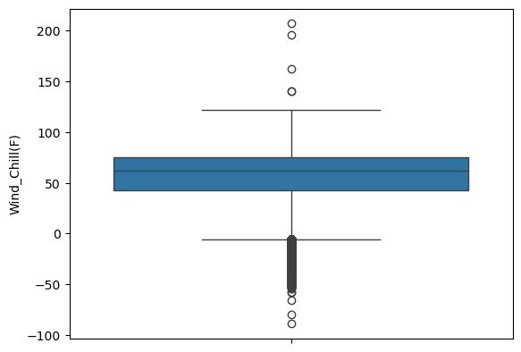

```python
sns.boxplot(data = df_clean, y = df_clean['Wind_Chill(F)'])
```

```python
Q1 = df_clean['Wind_Chill(F)'].quantile(.25)
Q2 = df_clean['Wind_Chill(F)'].quantile(.50)
Q3 = df_clean['Wind_Chill(F)'].quantile(.75)

IQR = Q3 - Q1

lowerfence = Q1 - (1.5 * IQR)
upperfence = Q3 + (1.5 * IQR)

print('Q1: ', Q1)
print('Q2: ', Q2)
print('Q3: ', Q3)

print('IQR: ', IQR)

print('lowerfence: ', lowerfence)
print('upperfence: ', upperfence)

print('Min: ', df['Wind_Chill(F)'].min())
print('Max: ', df['Wind_Chill(F)'].max())

print('median: ', df_clean['Wind_Chill(F)'].median())
```

```
Q1:  42.6
Q2:  62.0
Q3:  75.0
IQR:  32.4
lowerfence:  -5.999999999999993
upperfence:  123.6
Min:  -89.0
Max:  207.0
median:  62.0
```

### Outliers detected - So, I imputing the logic of Wind_Chill = Temperature(F) - (Wind_Speed(mph) * 0.7)

derive it from temperature when missing

```python
def calculate_wind_chill(row):
    # Rule1: Only calculate if Wind_Chill is missing and Temperature exists
    if pd.isna(row['Wind_Chill(F)']) and not pd.isna(row['Temperature(F)']):
        # Rule2: Apply wind chill formula only if wind speed > 3 mph
        if row['Wind_Speed(mph)'] > 3:
            return row['Temperature(F)'] - (row['Wind_Speed(mph)'] * 0.7)   #Simplified version of the NWS wind chill formula

        # Rule3: If wind speed <= 3 mph, wind chill = temperature
        return row['Temperature(F)']
    # Rule 4: Return original value if Wind_Chill isn't missing
    return row['Wind_Chill(F)']

df_clean['Wind_Chill(F)']= df_clean.apply(calculate_wind_chill, axis = 1)
```

```python
# Other columns with minimal missingness (<2%)
df_clean.dropna(subset= ['Street', 'City', 'Zipcode', 'Timezone', 'Weather_Timestamp', 'Astronomical_Twilight', 'Nautical_Twilight', 'Civil_Twilight', 'Sunrise_Sunset', 'Airport_Code', 'Description'], inplace=True)
```

### 2. Convert Data Types

```python
df_clean.head()
```

|  | ID | Source | Severity | Start_Time | End_Time | Start_Lat | Start_Lng | Distance(mi) | Description | Street | ... | Station | Stop | Traffic_Calming | Traffic_Signal | Turning_Loop | Sunrise_Sunset | Civil_Twilight | Nautical_Twilight | Astronomical_Twilight | Precipitation_occured |
| --- | --- | --- | --- | --- | --- | --- | --- | --- | --- | --- | --- | --- | --- | --- | --- | --- | --- | --- | --- | --- | --- |
| 0 | A-3 | Source2 | 2 | 2016-02-08 06:49:27 | 2016-02-08 07:19:27 | 39.063148 | -84.032608 | 0.01 | Accident on OH-32 State Route 32 Westbound at ... | State Route 32 | ... | False | False | False | True | False | Night | Night | Day | Day | 0 |
| 1 | A-6 | Source2 | 3 | 2016-02-08 07:44:26 | 2016-02-08 08:14:26 | 40.100590 | -82.925194 | 0.01 | Accident on I-270 Outerbelt Northbound near Ex... | Westerville Rd | ... | False | False | False | False | False | Day | Day | Day | Day | 1 |
| 2 | A-7 | Source2 | 2 | 2016-02-08 07:59:35 | 2016-02-08 08:29:35 | 39.758274 | -84.230507 | 0.00 | Accident on Oakridge Dr at Woodward Ave. Expec... | N Woodward Ave | ... | False | False | False | False | False | Day | Day | Day | Day | 0 |
| 3 | A-15 | Source2 | 2 | 2016-02-08 08:39:43 | 2016-02-08 09:09:43 | 39.972038 | -82.913521 | 0.01 | Accident on OH-16 Broad St at James Rd. Expect... | E Broad St | ... | False | False | False | True | False | Day | Day | Day | Day | 1 |
| 4 | A-39 | Source2 | 2 | 2016-02-09 05:17:08 | 2016-02-09 05:47:08 | 39.782578 | -84.178688 | 0.01 | Accident on Leo St at Kiser St. Expect delays. | Kiser St | ... | False | False | False | False | False | Night | Night | Night | Night | 0 |

5 rows × 44 columns

```python
# Convert timestamps
df_clean['Start_Time'] = pd.to_datetime(df_clean['Start_Time'], format='mixed')
df_clean['End_Time'] = pd.to_datetime(df_clean['End_Time'], format='mixed')
df_clean['Weather_Timestamp'] = pd.to_datetime(df_clean['Weather_Timestamp'], format='mixed')
```

```python
# Clean text fields
df_clean['Description'] = df_clean['Description'].str.strip()
df_clean['City'] = df_clean['City'].str.strip()
```

```python
# Check remaining missing values
print("Remaining missing values:")
print(df_clean.isnull().sum()[df_clean.isnull().sum() > 0])
```

```
Remaining missing values:
Series([], dtype: int64)
```

```python
#Save the cleaned file
df_clean.to_csv('US_Accidents_clean.csv', index=False)
```

## Step 5: Univariate Analysis

```python
#load the clean dataset
df_clean = pd.read_csv('US_Accidents_clean.csv')
display(df_clean)
```

|  | ID | Source | Severity | Start_Time | End_Time | Start_Lat | Start_Lng | Distance(mi) | Description | Street | ... | Station | Stop | Traffic_Calming | Traffic_Signal | Turning_Loop | Sunrise_Sunset | Civil_Twilight | Nautical_Twilight | Astronomical_Twilight | Precipitation_occured |
| --- | --- | --- | --- | --- | --- | --- | --- | --- | --- | --- | --- | --- | --- | --- | --- | --- | --- | --- | --- | --- | --- |
| 0 | A-3 | Source2 | 2 | 2016-02-08 06:49:27 | 2016-02-08 07:19:27 | 39.063148 | -84.032608 | 0.010 | Accident on OH-32 State Route 32 Westbound at ... | State Route 32 | ... | False | False | False | True | False | Night | Night | Day | Day | 0 |
| 1 | A-6 | Source2 | 3 | 2016-02-08 07:44:26 | 2016-02-08 08:14:26 | 40.100590 | -82.925194 | 0.010 | Accident on I-270 Outerbelt Northbound near Ex... | Westerville Rd | ... | False | False | False | False | False | Day | Day | Day | Day | 1 |
| 2 | A-7 | Source2 | 2 | 2016-02-08 07:59:35 | 2016-02-08 08:29:35 | 39.758274 | -84.230507 | 0.000 | Accident on Oakridge Dr at Woodward Ave. Expec... | N Woodward Ave | ... | False | False | False | False | False | Day | Day | Day | Day | 0 |
| 3 | A-15 | Source2 | 2 | 2016-02-08 08:39:43 | 2016-02-08 09:09:43 | 39.972038 | -82.913521 | 0.010 | Accident on OH-16 Broad St at James Rd. Expect... | E Broad St | ... | False | False | False | True | False | Day | Day | Day | Day | 1 |
| 4 | A-39 | Source2 | 2 | 2016-02-09 05:17:08 | 2016-02-09 05:47:08 | 39.782578 | -84.178688 | 0.010 | Accident on Leo St at Kiser St. Expect delays. | Kiser St | ... | False | False | False | False | False | Night | Night | Night | Night | 0 |
| ... | ... | ... | ... | ... | ... | ... | ... | ... | ... | ... | ... | ... | ... | ... | ... | ... | ... | ... | ... | ... | ... |
| 980383 | A-7777735 | Source1 | 4 | 2019-08-23 13:39:48 | 2019-08-23 14:05:33 | 33.687300 | -117.890190 | 0.243 | Ramp closed to Bristol St - Road closed due to... | San Diego Fwy S | ... | False | False | False | False | False | Day | Day | Day | Day | 0 |
| 980384 | A-7777747 | Source1 | 2 | 2019-08-23 16:26:06 | 2019-08-23 16:54:36 | 34.030470 | -117.598170 | 0.548 | At Archibald Ave - Accident. | Pomona Fwy E | ... | False | False | False | False | False | Day | Day | Day | Day | 0 |
| 980385 | A-7777748 | Source1 | 4 | 2019-08-23 16:51:29 | 2019-08-23 17:21:02 | 33.779130 | -117.887980 | 0.174 | Ramp closed to The City Dr/Exit 14A - Road clo... | CA-22 W | ... | False | False | False | False | False | Day | Day | Day | Day | 0 |
| 980386 | A-7777750 | Source1 | 2 | 2019-08-23 17:10:58 | 2019-08-23 17:40:28 | 33.850800 | -117.843650 | 0.356 | At Tustin Ave - Accident. | Riverside Fwy E | ... | False | False | False | False | False | Day | Day | Day | Day | 0 |
| 980387 | A-7777758 | Source1 | 2 | 2019-08-23 19:11:30 | 2019-08-23 19:38:23 | 32.766960 | -117.148060 | 0.338 | At Camino Del Rio/Mission Center Rd - Accident. | I-8 W | ... | False | False | False | False | False | Day | Day | Day | Day | 0 |

980388 rows × 44 columns

```python
# For numerical variables
num_cols = df_clean.select_dtypes(include= ['int64', 'float64']).columns
for col in num_cols[:5]:
    #print(col)
    #sns.histplot(data = df_clean, x = col, kde= True)
    fig = px.histogram(data_frame=df_clean, x=col, title= f'Distribution of {col}')
    fig.show()
```

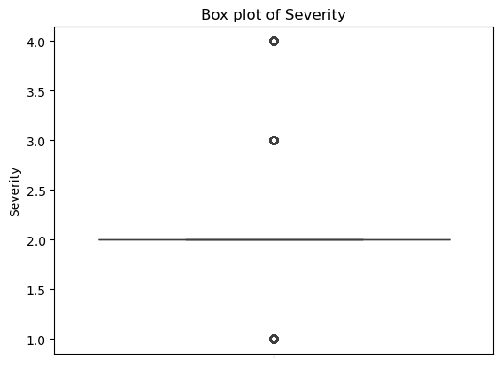

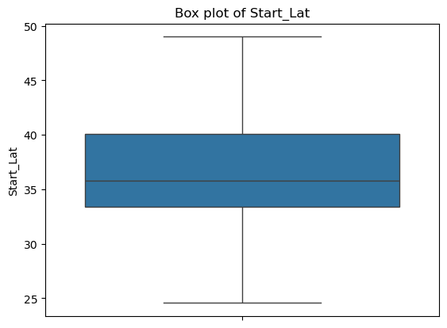

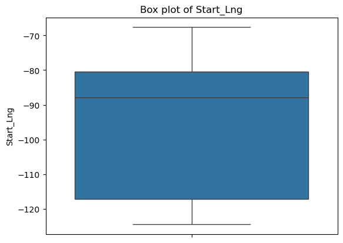

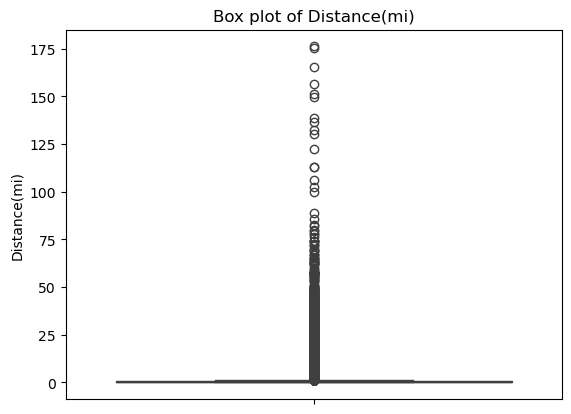

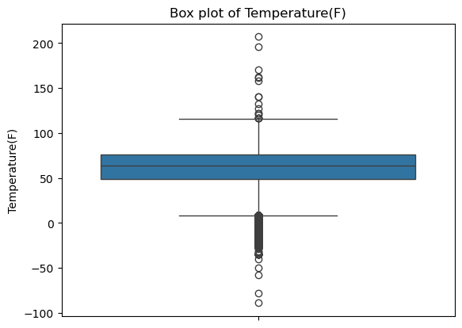

```python
# Boxplot to check outliers
for col in num_cols[:5]:
    sns.boxplot(data= df_clean, y = col)
    plt.title(f"Box plot of {col}")
    plt.show()
```

```python
df_clean.info()
```

```
<class 'pandas.core.frame.DataFrame'>
RangeIndex: 980388 entries, 0 to 980387
Data columns (total 44 columns):
 #   Column                 Non-Null Count   Dtype
---  ------                 --------------   -----
 0   ID                     980388 non-null  object
 1   Source                 980388 non-null  object
 2   Severity               980388 non-null  int64
 3   Start_Time             980388 non-null  object
 4   End_Time               980388 non-null  object
 5   Start_Lat              980388 non-null  float64
 6   Start_Lng              980388 non-null  float64
 7   Distance(mi)           980388 non-null  float64
 8   Description            980388 non-null  object
 9   Street                 980388 non-null  object
```

[output cut: 36 more lines]

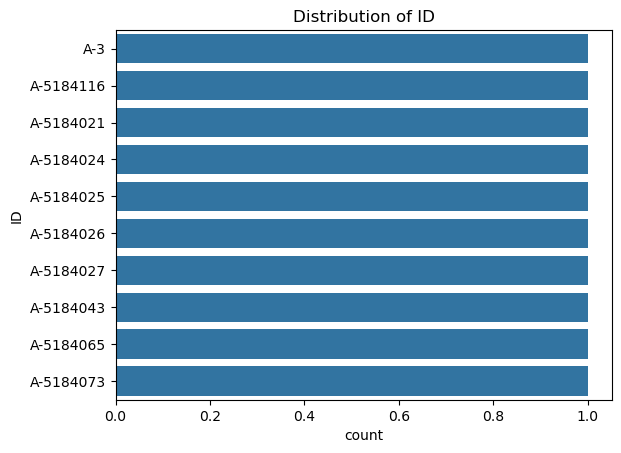

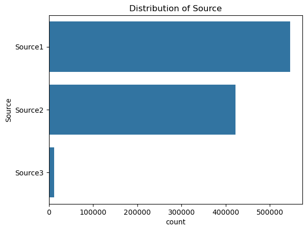

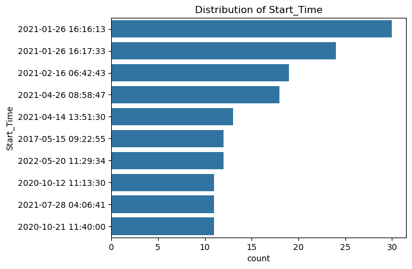

```python
# For categorical variables
cat_cols = df_clean.select_dtypes(include = ['object']).columns
for col in cat_cols[:3]:
    sns.countplot(data=df_clean, y=col, order=df_clean[col].value_counts().index[:10])
    plt.title(f"Distribution of {col}")
    plt.show()
```

## Step 6: Time Series Analysis

```python
print(df_clean['Start_Time'].dtype)
```

```
object
```

```python
# Extract time components
df_clean['Start_Time'] = pd.to_datetime(df_clean['Start_Time'])

df_clean['year'] = df_clean['Start_Time'].dt.year
df_clean['Month'] = df_clean['Start_Time'].dt.month
df_clean['Day'] = df_clean['Start_Time'].dt.day
df_clean['Hour'] = df_clean['Start_Time'].dt.hour
df_clean['DayOfWeek'] = df_clean['Start_Time'].dt.dayofweek  # Monday=0, Sunday=6
```

```python
print(df_clean['Start_Time'].dtype)
```

```
datetime64[ns]
```

```python
#Save the cleaned file
df_clean.to_csv('US_Accidents_clean.csv', index=False)
```

```python
for i in ['year', 'Month', 'Day', 'Hour', 'DayOfWeek']:
    fig = px.histogram(
        df_clean,
        x=i,
        title=f'Accidents by {i}',
        nbins=len(df_clean[i].unique()),
        text_auto = True,
        color= i,
        color_discrete_sequence=px.colors.qualitative.Pastel
    ).update_layout(bargap = 0.1)  # One bin per year
    fig.show()
```

```python
# plot by state
fig = px.bar(df_clean['State'].value_counts()[:10], title= 'Accidents by state (Top 10)', text_auto= True)
fig.show()
```

## Questions from insights

### 1. How do accidents vary by time of day?

```python
fig = px.histogram(data_frame= df_clean,
                   x = 'Hour',
                   nbins= len(df_clean['Hour'].unique()),
                   title= "Accidents vary by time of the day",
                   text_auto= True).update_layout(bargap = 0.1)
fig.show()
```

### 2. Which days of the week have most accidents?

```python
fig = px.histogram(data_frame= df_clean,
                   x = 'DayOfWeek',
                   nbins= len(df_clean['DayOfWeek'].unique()),
                   title= "Accidents by Day of Week",
                   text_auto= True
                   ).update_layout(bargap = 0.1)
fig.show()
```

### 3. How does accident severity distribute?

```python
df_clean['Severity'].unique()
```

```
array([2, 3, 1, 4])
```

```python
fig = px.histogram(data_frame= df_clean,
                   x = 'Severity',
                   #nbins= len(df_clean['Severity'].unique()),
                   title= "Distribution of Accident Severity Levels",
                   text_auto= True,
                   color_discrete_sequence=['Red']
                   ).update_layout(bargap = 0.1)
fig.show()
```

### 4. Which states have the highest accident frequency?

```python
df_clean['State'].unique()[:10]
```

```
array(['OH', 'CA', 'FL', 'GA', 'SC', 'NE', 'IA', 'MO', 'IL', 'WI'],
      dtype=object)
```

```python
fig = px.bar(df_clean['State'].value_counts()[:10],
                   title= "Accidents by state",
                   text_auto= True
                   ).update_layout(bargap = 0.1)
fig.show()
```

### 5. What's the relationship between weather conditions and severity?

```python
top_weather_df = df_clean['Weather_Condition'].value_counts().head(10).index
weather_df = df_clean[df_clean['Weather_Condition'].isin(top_weather_df)]

display(top_weather_df)
display(weather_df.head())
```

```
Index(['Fair', 'Mostly Cloudy', 'Cloudy', 'Clear', 'Partly Cloudy', 'Overcast',
       'Light Rain', 'Scattered Clouds', 'Light Snow', 'Fog'],
      dtype='object', name='Weather_Condition')
```

|  | ID | Source | Severity | Start_Time | End_Time | Start_Lat | Start_Lng | Distance(mi) | Description | Street | ... | Sunrise_Sunset | Civil_Twilight | Nautical_Twilight | Astronomical_Twilight | Precipitation_occured | year | Month | Day | Hour | DayOfWeek |
| --- | --- | --- | --- | --- | --- | --- | --- | --- | --- | --- | --- | --- | --- | --- | --- | --- | --- | --- | --- | --- | --- |
| 0 | A-3 | Source2 | 2 | 2016-02-08 06:49:27 | 2016-02-08 07:19:27 | 39.063148 | -84.032608 | 0.01 | Accident on OH-32 State Route 32 Westbound at ... | State Route 32 | ... | Night | Night | Day | Day | 0 | 2016 | 2 | 8 | 6 | 0 |
| 1 | A-6 | Source2 | 3 | 2016-02-08 07:44:26 | 2016-02-08 08:14:26 | 40.100590 | -82.925194 | 0.01 | Accident on I-270 Outerbelt Northbound near Ex... | Westerville Rd | ... | Day | Day | Day | Day | 1 | 2016 | 2 | 8 | 7 | 0 |
| 2 | A-7 | Source2 | 2 | 2016-02-08 07:59:35 | 2016-02-08 08:29:35 | 39.758274 | -84.230507 | 0.00 | Accident on Oakridge Dr at Woodward Ave. Expec... | N Woodward Ave | ... | Day | Day | Day | Day | 0 | 2016 | 2 | 8 | 7 | 0 |
| 3 | A-15 | Source2 | 2 | 2016-02-08 08:39:43 | 2016-02-08 09:09:43 | 39.972038 | -82.913521 | 0.01 | Accident on OH-16 Broad St at James Rd. Expect... | E Broad St | ... | Day | Day | Day | Day | 1 | 2016 | 2 | 8 | 8 | 0 |
| 4 | A-39 | Source2 | 2 | 2016-02-09 05:17:08 | 2016-02-09 05:47:08 | 39.782578 | -84.178688 | 0.01 | Accident on Leo St at Kiser St. Expect delays. | Kiser St | ... | Night | Night | Night | Night | 0 | 2016 | 2 | 9 | 5 | 1 |

5 rows × 49 columns

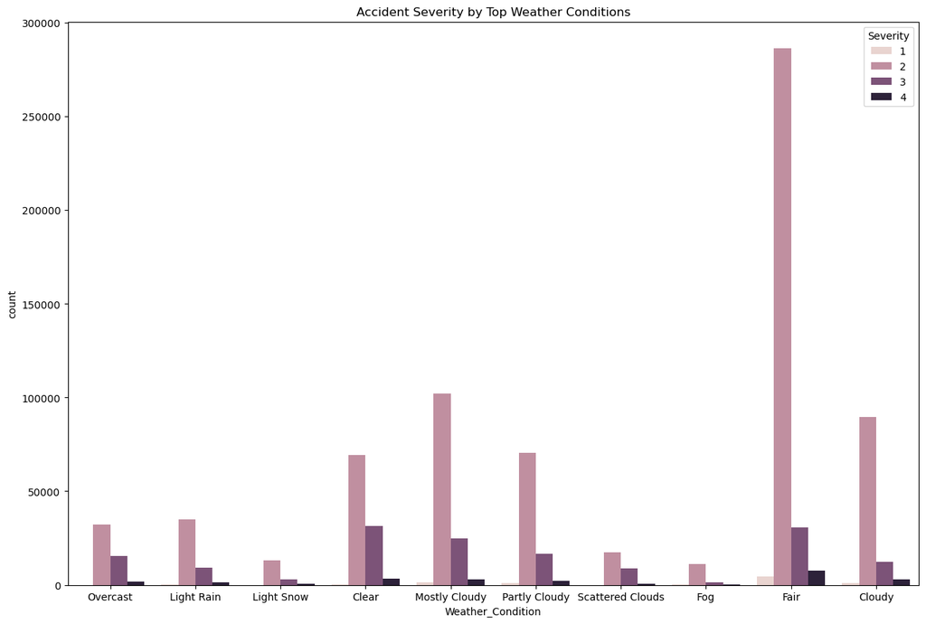

```python
plt.figure(figsize=(15, 10))
sns.countplot(data = weather_df, x = weather_df['Weather_Condition'], hue = weather_df['Severity'])
plt.title('Accident Severity by Top Weather Conditions')
plt.show()
```

### 6. What's the temperature distribution during accidents?

```python
df_clean['Temperature(F)'].unique()[0:10]
```

```
array([36. , 37.9, 34. , 37.4, 22.8, 25. , 26.1, 24.8, 27. , 15.1])
```

```python
fig = px.histogram(data_frame= df_clean,
                   x = df_clean['Temperature(F)'],
                   nbins = 50,
                   title= "Temperature Distribution During Accidents",
                   text_auto= True
                   ).update_layout(bargap = 0.1)
fig.show()
```

### 7. How do accidents vary by light conditions?

```python
df_clean['Sunrise_Sunset'].unique()
```

```
array(['Night', 'Day'], dtype=object)
```

```python
fig = px.histogram(data_frame= df_clean,
                   x = df_clean['Severity'],
                   color= df_clean['Sunrise_Sunset'],
                   barmode= 'group',
                   title= "Accidents by Daylight vs Night",
                   text_auto= True
                   )
fig.show()
```

### Conclusion

-- Most accidents happen during the day, fewer accidents happen late at night, maybe because fewer cars are on the road.

-- Accidents mostly occur when temperatures are between 50°F and 80°F – normal driving weather.

-- California, Florida, and Texas have the highest number of accidents – probably because they have more people and traffic.

-- Accidents are more common on weekdays, especially on Fridays. Fewer happen on weekends.

-- Accidents peak during morning (7-8 AM) and evening (4–6 PM) rush hours, when people go to and return from work.